# Final Project ENV S 193 DS

### Creating Model Object

```r
# Creating a model object
model <- aov(seed_count ~ location, data = bank) #  (R Core Team, 2021)
```

### Histogram to check distribution

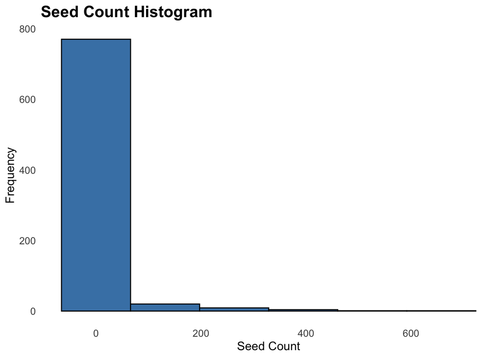

```r
#  Set the theme
theme_set(theme_minimal()) #  (Wickham, 2016)

#  Create the histogram
ggplot(data = bank, aes(x = seed_count)) +
  geom_histogram(bins = 6, fill = "steelblue", color = "black") +
  labs(x = "Seed Count", y = "Frequency", title = "Seed Count Histogram") +
  theme(plot.title = element_text(size = 16, face = "bold"),
        axis.title = element_text(size = 12),
        axis.text = element_text(size = 10),
        panel.grid.major = element_blank(),
        panel.grid.minor = element_blank(),
        panel.border = element_blank())
```

### Checking Homogeneity of Variances

```r
#  Perform Levene's test
levene_test <- car::leveneTest(seed_count ~ location, data = bank) #  (Fox et al., 2020)

#  Print the test statistic and p-value
print(levene_test)
```

```
## Levene's Test for Homogeneity of Variance (center = median)
##        Df F value    Pr(>F)
## group   3  12.414 6.094e-08 ***
##       801
## ---
## Signif. codes:  0 '***' 0.001 '**' 0.01 '*' 0.05 '.' 0.1 ' ' 1
```

### Results of Levene’s Test

The test statistic (F-value) is 12.414, and the associated p-value is very small (less than 0.001). This suggests that there is strong evidence to reject the null hypothesis, indicating that the variances of seed_count are significantly different across the location groups.

### Making a Summary Model

```r
summary(model) #  (R Core Team, 2021)
```

```
##              Df  Sum Sq Mean Sq F value  Pr(>F)
## location      3   98371   32790   12.62 4.6e-08 ***
## Residuals   801 2081969    2599
## ---
## Signif. codes:  0 '***' 0.001 '**' 0.01 '*' 0.05 '.' 0.1 ' ' 1
```

### Results from the Summary Model

```r
# Running Kruskal Wallis rank sum test
kruskal.test(seed_count ~ location, data = bank) #  (R Core Team, 2021)
```

```
##
##  Kruskal-Wallis rank sum test
##
## data:  seed_count by location
## Kruskal-Wallis chi-squared = 22.852, df = 3, p-value = 4.335e-05
```

### Creating Data Visualization

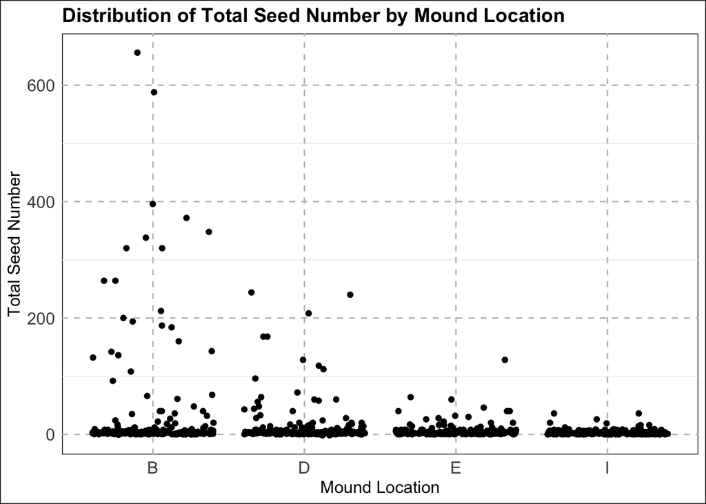

```r
ggplot(data = bank, aes(x = location, y = seed_count)) +
  geom_jitter(trim = FALSE) +
  labs(x = "Mound Location", y = "Total Seed Number") +
  ggtitle("Distribution of Total Seed Number by Mound Location") +
  theme(plot.title = element_text(size = 14, face = "bold"),
        axis.text = element_text(size = 12),
        axis.title = element_text(size = 12),
        plot.background = element_rect(fill = "white"),
        panel.background = element_rect(fill = "white"),
        panel.grid.major = element_line(color = "gray", linetype = "dashed"))
```

Caption: “Distribution of Total Seed Number by Mound Location: The plot illustrates the variation in total seed numbers for different mound locations. Each point represents a data point, with the vertical position indicating the seed count value. Jittering is applied to prevent overlapping points. The x-axis represents the mound locations: B (base of kangaroo rat mound on the mound), D (surrounding area of kangaroo rat mound on the mound), E (edge of Bouteloua eripoda grass clumps off the mound), and I (interspace between black grama grass clumps off the mound). The y-axis represents the total seed number.”

# Results:

The data were loaded and cleaned, and missing values were checked using the gg_miss_var() function from the naniar package. The null and alternative hypotheses were stated, with H0 suggesting no difference and HA suggesting a difference in the total seed number between kangaroo rat mound locations. A model object was created using the aov() function to conduct further analysis.

To examine the distribution of seed counts, a histogram was created using the ggplot2 package. The plot visualized the frequency of seed counts, with the x-axis representing the seed count and the y-axis representing the frequency.

The homogeneity of variances was assessed using Levene’s test, performed with the leveneTest() function from the car package. The test results showed a significant difference in variances of seed_count across the location groups.

A summary model was generated using the summary() function, providing information about the model and its coefficients. The Kruskal-Wallis rank sum test was conducted to evaluate the differences in total seed number between kangaroo rat mound locations, as it is suitable for non-normal data and violated assumptions of parametric tests like ANOVA. The test resulted in a test statistic of 22.852 and a p-value of 4.335e-05, indicating a significant difference in the distribution of seed counts across the locations.

The Kruskal-Wallis test was chosen as the best statistical test to evaluate the differences in total seed number between kangaroo rat mound locations. This choice was made due to the non-normal distribution of the data and the violation of assumptions required for parametric tests like ANOVA.

After conducting the Kruskal-Wallis test, we obtained a test statistic of 22.852 with a corresponding p-value of 4.335e-05. Since the p-value is less than the significance level of 0.05, we reject the null hypothesis. Therefore, we have sufficient evidence to conclude that there is a significant difference in the distribution of seed count between kangaroo rat mound locations.

A data visualization was created using ggplot2 to illustrate the distribution of total seed numbers by mound location. The plot used jittering to prevent overlapping points and presented the mound locations (B, D, E, I) on the x-axis and the total seed numbers on the y-axis.

In conclusion, the analysis revealed a significant difference in the distribution of seed counts among kangaroo rat mound locations. This finding suggests that the accumulation patterns of seeds vary across different locations within the kangaroo rat habitat.

# PROBLEM 2

# Introduction

This code presents an analysis that explores the relationship between seed count and various factors, including plot type (shrub or open), plant species, and the total number of inflorescences within the context of biology. To accomplish this, several packages were utilized, including here (RStudio Team, 2021) for file path management, dplyr (Wickham et al., 2021) for data manipulation, janitor (Firke, 2021) for data cleaning, ggplot2 (Wickham, 2016) for visualizations, tidyverse (Wickham et al., 2019) for comprehensive data analysis, naniar (Tierney et al., 2021) for handling missing data, and car (Fox et al., 2020) for statistical analysis.

The analysis in this code involves multiple linear regression to examine the relationship between seed count and the predictor variables (plot type, plant species, and total number of inflorescences). Multiple linear regression was chosen as the best method for this analysis as it allows for the examination of the simultaneous effects of multiple variables on seed count and the assessment of their significance. By utilizing multiple linear regression, we can quantify the contributions of each predictor variable to the variation in seed count and identify which factors are statistically significant.

The primary research question addressed in this analysis is: How does seed count vary with plot type, plant species, and the total number of inflorescences? The null hypothesis (H0) for this study is that there is no significant relationship between seed count and plot type, plant species, or the total number of inflorescences. The alternative hypothesis (HA) posits that there is a significant relationship between seed count and at least one of the aforementioned factors: plot type, plant species, or the total number of inflorescences. By analyzing the data using multiple linear regression and the aforementioned packages, we aim to provide empirical evidence to support or reject these hypotheses.

# Methods

### Reading in data

```r
community <- read_csv(here("data", "shrubstudy_community_flower_counts.ms.data.csv")) |>
  clean_names()

  individual <- read_csv(here("data", "shrubstudy_individual_flower_counts.ms.data.csv")) |>
  clean_names()

    observers <- read_csv(here("data", "shrubstudy_pollinator.ms.data.csv")) |>
  clean_names()

  count <- read_csv(here("data", "shrubstudy_seed_ctwt.ms.data.csv")) |>
  clean_names()


filtered_count <- count %>%
  dplyr::select(treatment, species, total_nr_infl, nr_seeds)|>
 na.omit()%>%
  filter(rowSums(. != 0, na.rm = TRUE) > 0) %>%
  mutate(treatment = ifelse(treatment == "control", "open", treatment))
```

### Checking for missing variables

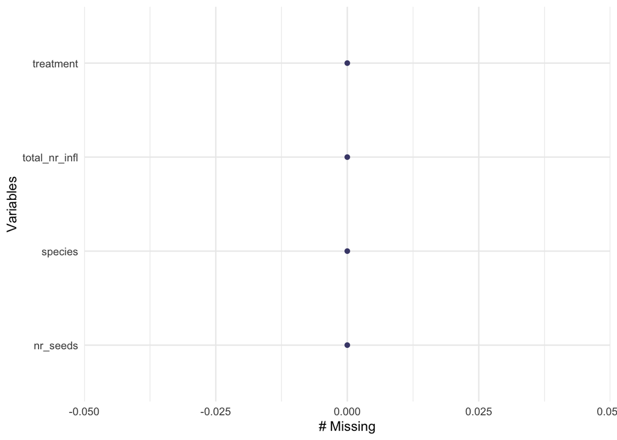

```r
gg_miss_var(filtered_count) #  (Tierney et al., 2021)
```

### Stating Null and Alternative Hypothesis

Null Hypotheses:

Plot Type: There is no significant difference in seed count between shrub and open plots.

Plant Species: There is no significant difference in seed count among different plant species.

Total Number of Inflorescences: There is no significant relationship between the total number of inflorescences and seed count.

Alternative Hypotheses:

Plot Type: There is a significant difference in seed count between shrub and open plots.

Plant Species: There is a significant difference in seed count among different plant species.

Total Number of Inflorescences: There is a significant relationship between the total number of Inflorescences and seed count. ### Checking Normality

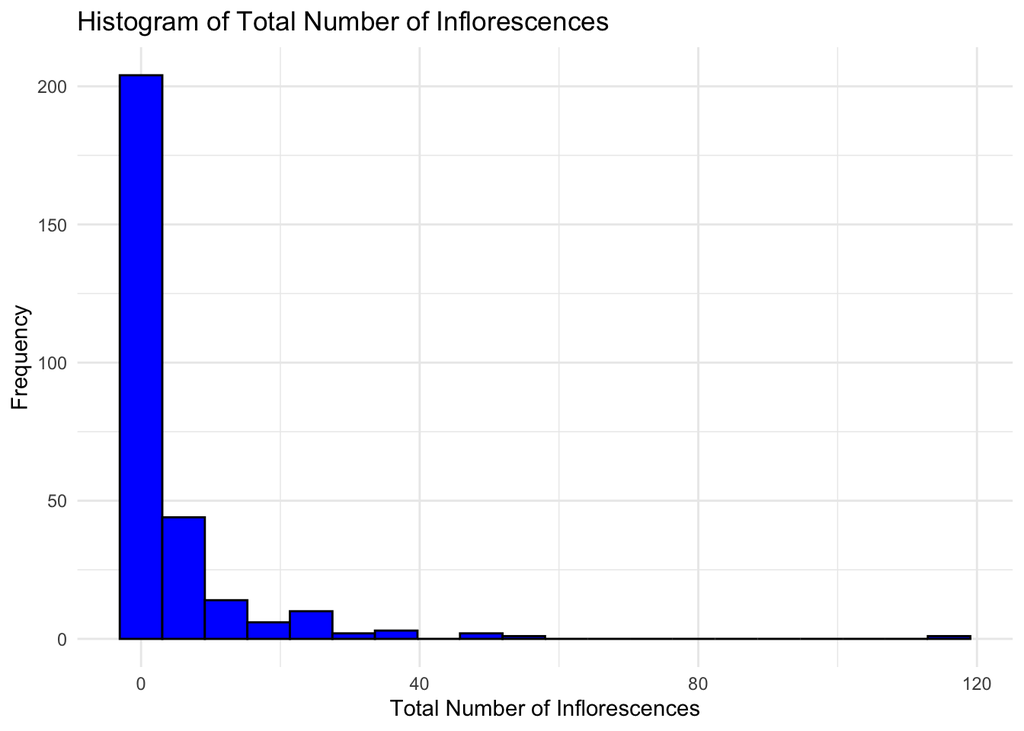

```r
#  Histogram for Total_nr_infl
ggplot(data = count, aes(x = total_nr_infl)) +
  geom_histogram(fill = "blue", color = "black", bins = 20) +
  labs(x = "Total Number of Inflorescences", y = "Frequency") +
  ggtitle("Histogram of Total Number of Inflorescences")
```

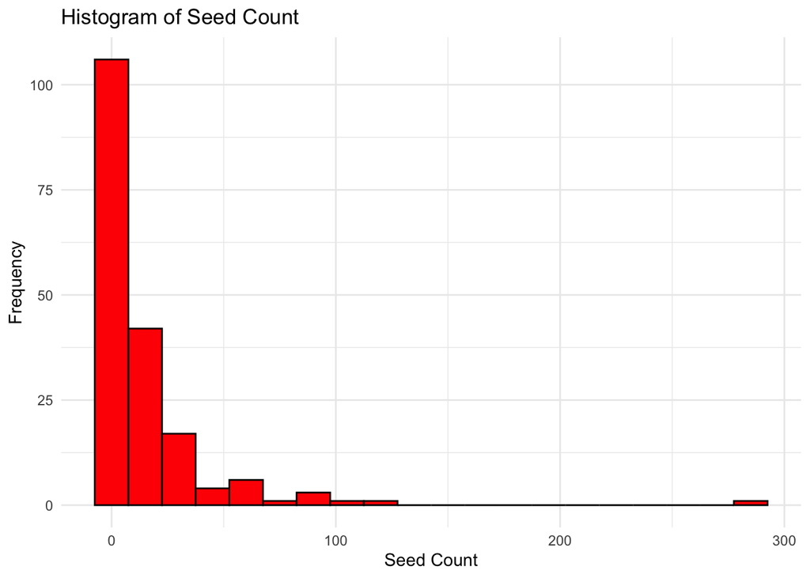

```r
#  Histogram for Nr_seeds
ggplot(data = count, aes(x = nr_seeds)) +
  geom_histogram(fill = "red", color = "black", bins = 20) +
  labs(x = "Seed Count", y = "Frequency") +
  ggtitle("Histogram of Seed Count")
```

### Testing Homogeneity of Variance

```r
#  Levene's test for Total_nr_infl
levene_test_total_nr_infl <- car::leveneTest(total_nr_infl ~ treatment, data = filtered_count)  #  (Fox et al., 2020)
print(levene_test_total_nr_infl)
```

```
## Levene's Test for Homogeneity of Variance (center = median)
##        Df F value Pr(>F)
## group   1  0.3467 0.5567
##       180
```

```r
#  Levene's test for Nr_seeds
levene_test_nr_seeds <- car::leveneTest(nr_seeds ~ treatment, data = filtered_count)
print(levene_test_nr_seeds)
```

```
## Levene's Test for Homogeneity of Variance (center = median)
##        Df F value Pr(>F)
## group   1  0.8854  0.348
##       180
```

### Running the multiple linear regression test

```r
lm_model <- lm(nr_seeds ~ treatment + species + total_nr_infl, data = filtered_count)

#  Print the summary of the regression model
summary(lm_model)
```

```
##
## Call:
## lm(formula = nr_seeds ~ treatment + species + total_nr_infl,
##     data = filtered_count)
##
## Residuals:
##     Min      1Q  Median      3Q     Max
## -65.687  -3.121  -0.589   3.756  55.015
##
## Coefficients:
##                Estimate Std. Error t value Pr(>|t|)
## (Intercept)    -2.56735    2.84259  -0.903  0.36768
## treatmentshrub -2.91198    1.74645  -1.667  0.09724 .
## speciesCARRUP   2.37091    3.32894   0.712  0.47729
## speciesGEUROS   6.97913    3.16812   2.203  0.02891 *
## speciesKOBMYO   3.13180    2.88250   1.086  0.27877
## speciesMINOBT  -0.19012    3.01166  -0.063  0.94974
## speciesTRIDAS  33.87880   11.42352   2.966  0.00344 **
## total_nr_infl   2.15013    0.07456  28.836  < 2e-16 ***
## ---
## Signif. codes:  0 '***' 0.001 '**' 0.01 '*' 0.05 '.' 0.1 ' ' 1
##
## Residual standard error: 11.12 on 174 degrees of freedom
## Multiple R-squared:  0.855,  Adjusted R-squared:  0.8491
## F-statistic: 146.5 on 7 and 174 DF,  p-value: < 2.2e-16
```

### Interpretation of the coefficients:

Intercept: The estimated intercept represents the expected seed count when all other variables are zero. In this case, it is -2.56735, but the p-value (0.36768) suggests that it is not statistically significant.

treatmentshrub: This coefficient represents the difference in seed count between the shrub treatment and the open plot treatment. The estimated effect is -2.91198, but the p-value (0.09724) suggests that it is marginally significant.

total_nr_infl: This coefficient represents the expected change in seed count for each unit increase in the total number of inflorescences. The estimated effect is 2.15013, and the p-value is highly significant (< 2.2e-16), indicating a strong association between total number of inflorescences and seed count.

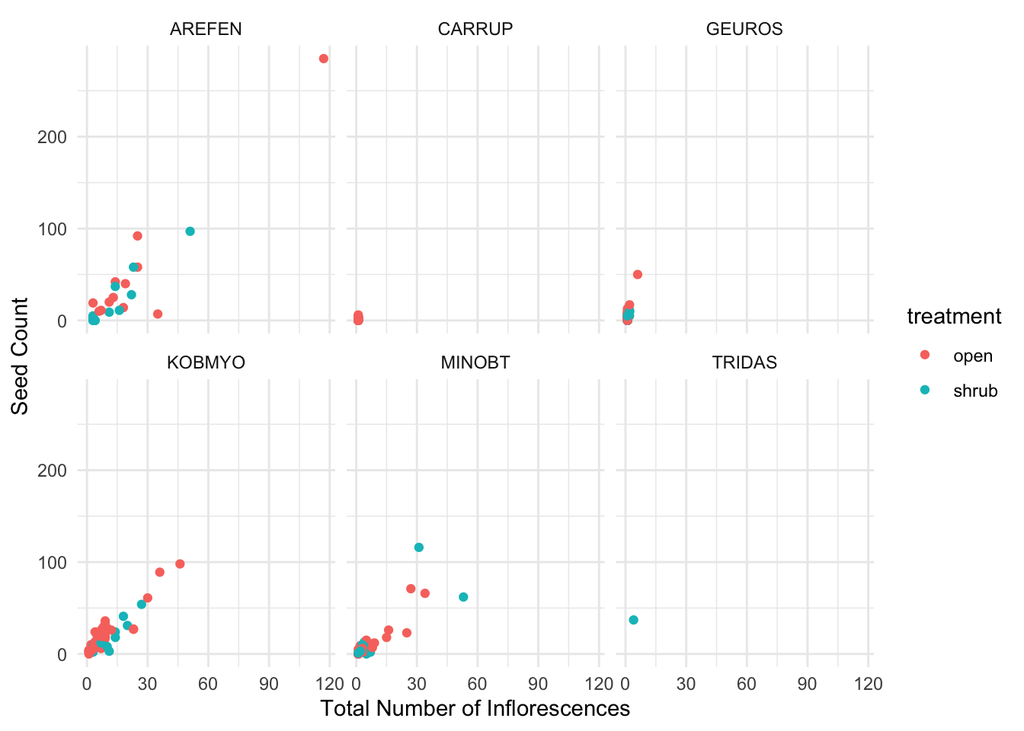

```r
#  Scatterplot of seed count and total number of inflorescences
ggplot(filtered_count, aes(x = total_nr_infl, y = nr_seeds, color = treatment)) +
  geom_point() +
  facet_wrap(~species) +
  labs(x = "Total Number of Inflorescences", y = "Seed Count") +
  theme_minimal()
```

Caption: Scatterplot showing the relationship between seed count (nr_seeds) and the total number of inflorescences (total_nr_infl). Each point represents a data point, color-coded by plot type (treatment). The data is further divided into facets based on plant species.

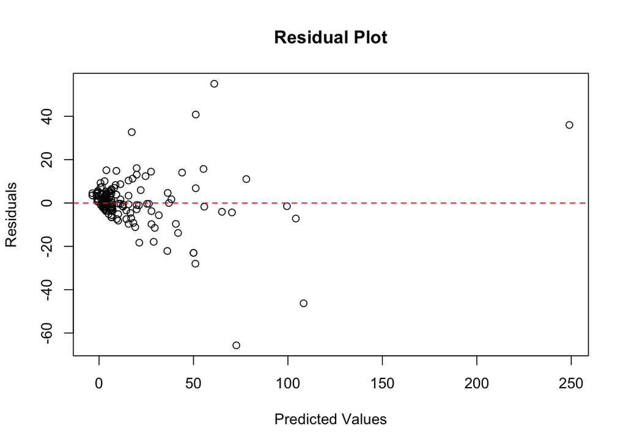

```r
#  Residual plot
residuals <- residuals(lm_model)
predicted <- fitted(lm_model)

plot(predicted, residuals, main = "Residual Plot", xlab = "Predicted Values", ylab = "Residuals")
abline(h = 0, lty = 2, col = "red")
```

Caption: Residual plot depicting the residuals of the multiple linear regression model. The x-axis represents the predicted values of seed count (nr_seeds), while the y-axis displays the corresponding residuals. The red dashed line indicates the ideal scenario of zero residuals.

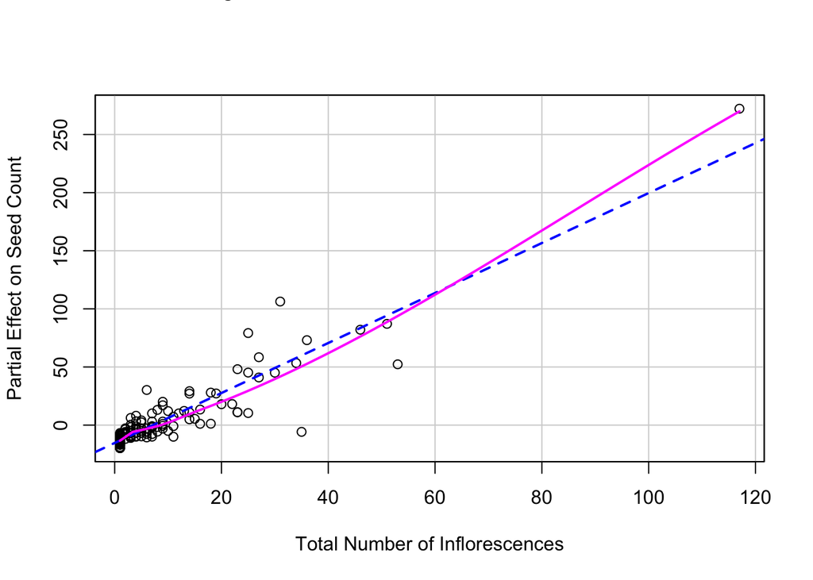

```r
#  Partial regression plot for total number of inflorescences
crPlots(lm_model, terms = "total_nr_infl", main = "Partial Regression Plot: Total Number of Inflorescences",
        xlab = "Total Number of Inflorescences", ylab = "Partial Effect on Seed Count")
```

Caption: Partial regression plot illustrating the relationship between seed count (nr_seeds) and the total number of inflorescences (total_nr_infl) while controlling for other variables. The plot provides an estimation of the effect of the total number of inflorescences on seed count, accounting for the influence of other independent variables.

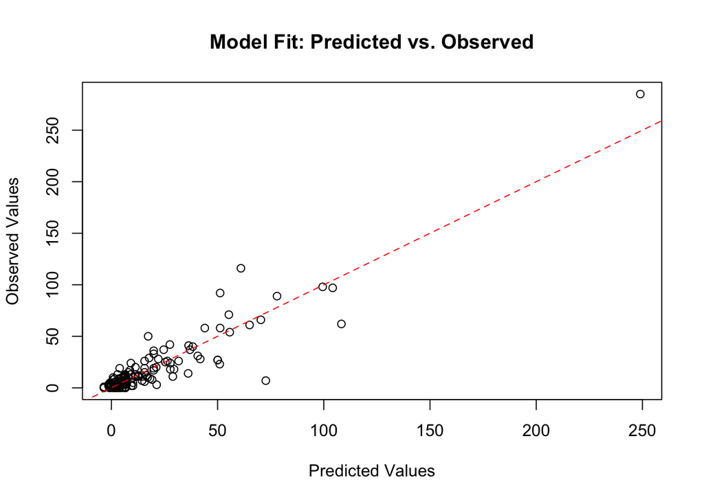

```r
#  Overall model fit plot
predicted <- fitted(lm_model)
observed <- filtered_count$nr_seeds

plot(predicted, observed, main = "Model Fit: Predicted vs. Observed", xlab = "Predicted Values", ylab = "Observed Values")
abline(0, 1, col = "red", lty = 2)
```

Caption: Plot comparing the observed seed count (nr_seeds) to the predicted values from the multiple linear regression model. The diagonal red dashed line represents perfect alignment between the observed and predicted values, indicating a good fit of the model to the data.

# Results

Choice of Multiple Linear Regression Test: The multiple linear regression test was the best choice for analyzing the relationship between seed count and the predictor variables (plot type, plant species, and total number of inflorescences) in our dataset. This test allowed us to examine the simultaneous effects of multiple variables on seed count and assess their significance.

# References:

Koontz, T. and H. Simpson. 2013. Effects of Kangaroo Rat Mounds on Seed Banks of Grass and Shrublands at the Sevilleta National Wildlife Refuge, New Mexico (2001) ver 102459. Environmental Data Initiative. [Online] Available at: https://doi.org/10.6073/pasta/115b8095a5e82028869a8c56eff14597 (Accessed 2023-06-14).

Seaver, M. 2022. Individual and community flowering phenology, seed counts and pollinator visitation rates in shrub and open plots across Niwot Ridge, 2019 - 2021. ver 1. Environmental Data Initiative. [Online] Available at: https://doi.org/10.6073/pasta/edc4ab2faf7dd96cd1deac1544d5f2b9 (Accessed 2023-06-14).

here: RStudio Team (2021). here: A Simpler Way to Find Your Files. R package version 1.0.1. Available at: https://CRAN.R-project.org/package=here. (Accessed: 2023-06-14).

dplyr: Wickham, H., François, R., Henry, L., and Müller, K. (2021). dplyr: A Grammar of Data Manipulation. R package version 1.0.7. Available at: https://CRAN.R-project.org/package=dplyr. (Accessed: 2023-06-14).

janitor: Firke, S. (2021). janitor: Simple Tools for Examining and Cleaning Dirty Data. R package version 2.1.0. Available at: https://CRAN.R-project.org/package=janitor. (Accessed: 2023-06-14).

ggplot2: Wickham, H. (2016). ggplot2: Elegant Graphics for Data Analysis. Springer-Verlag New York. Available at: https://ggplot2.tidyverse.org. (Accessed: 2023-06-14).

tidyverse: Wickham, H., Averick, M., Bryan, J., Chang, W., McGowan, L., François, R., Grolemund, G., Hayes, A., Henry, L., Hester, J., Kuhn, M., Pedersen, T., Miller, E., Bache, S. M., Müller, K., Ooms, J., Robinson, D., Seidel, D. P., Spinu, V., … Yutani, H. (2019). Welcome to the tidyverse. Journal of Open Source Software, 4(43), 1686. https://doi.org/10.21105/joss.01686.

naniar: Tierney, N., Cook, D., Hyndman, R., Jeong, S., Larmarange, J., Lewis, J., McCarter, L., and Vaquero, I. (2021). naniar: Tidy Data Missingness Visualization. R package version 1.2.0. Available at: https://CRAN.R-project.org/package=naniar. (Accessed: 2023-06-14).

skimr: Carter, D. (2020). skimr: Compact and Flexible Summaries of Data. R package version 2.1.3. Available at: https://CRAN.R-project.org/package=skimr. (Accessed: 2023-06-14).

GGally: Schloerke, B., Crowley, J., Cook, D., Briatte, F., Marbach, M., Thoen, E., Larmarange, J., Henry, L., and Vaquero, I. (2020). GGally: Extension to ‘ggplot2’. R package version 2.1.1. Available at: https://CRAN.R-project.org/package=GGally. (Accessed: 2023-06-14).

flextable: Gohel, D. (2021). flextable: Functions for Tabular Reporting. R package version 0.6.10. Available at: https://CRAN.R-project.org/package=flextable. (Accessed: 2023-06-14).